# UNIT08D：多元尺度分析(MDS)與品牌知覺圖

中山大學管理學院 卓雍然

2022-04-30 14:14:32

💡 學習重點：  
■ 多元尺度分析(MDS, Multi-Dimension Scaling)  
§ 縮減尺度工具  
§ 盡量維持持高、低尺度之中各資料點間的距離  
■ 品牌知覺圖(Perception Map)：呈現在消費者心中  
§ 品牌與品牌間的關係  
§ 屬性與屬性間的關係  
§ 品牌與屬性之間的關係

```r
pacman::p_load(dplyr, FactoMineR, factoextra)
```

##### § Reading and Preapring Data

```r
load("data/cafe.rdata")
row.names(cafe) = cafe[,1]
cafe = cafe[,-1]
cafe
```

```
         種類樣式 產品風格 整體產品 公司形象 品牌印象 知名度 專業表現 可信度
丹堤         3.10     2.55     2.85     2.98     2.28   2.66     2.42   2.22
星巴克       2.35     2.68     2.84     3.21     2.07   3.27     2.62   2.22
八五度       3.23     2.69     2.79     2.77     2.73   2.65     2.13   1.99
壹咖啡       2.90     2.62     2.74     2.70     2.57   2.66     2.41   2.09
理想品牌     2.56     3.17     3.19     2.71     1.72   2.23     2.81   2.50
```

這裡我們有5個品牌(資料點)、8種屬性(尺度)，儘管資料點數不多，我們還是很難同時想像八個尺度

### 1. Multi-Dimensional Scaling (多元尺度分析)

- Calculate the distance matrix by `dist()`
- Call `cmdscale()` for MDS analysis.

```r
d = dist(cafe, method = "euclidean")
fit <- cmdscale(d, eig = TRUE, k = 2)
```

- Then plot the brands on the space of reduced dimensions.

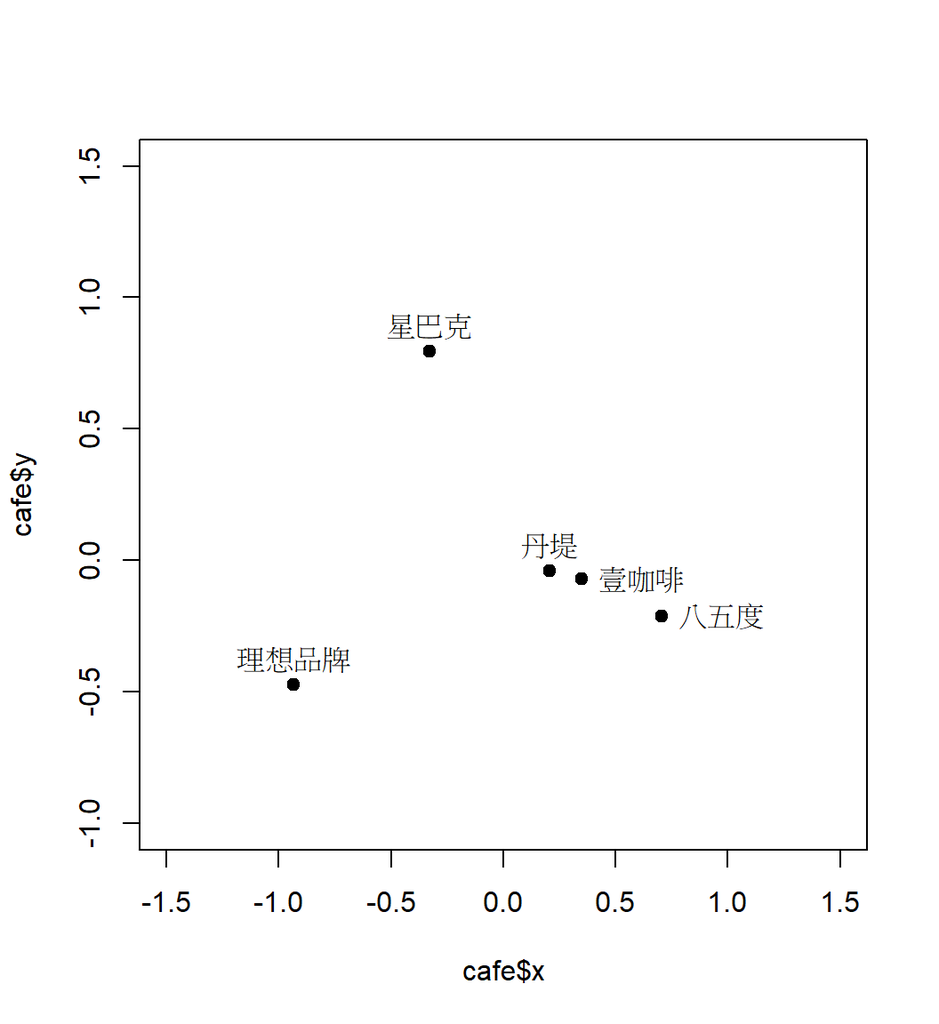

```r
brands = rownames(cafe); percepts=colnames(cafe) #percepts:知覺
cafe$x = fit$points[, 1]
cafe$y = fit$points[, 2]
plot(cafe$x, cafe$y, pch = 19, xlim=c(-1.5,1.5), ylim=c(-1,1.5))
bpos = c(3, 3, 4, 4, 3)
text(cafe$x, cafe$y, pos=bpos, offset=0.5, labels = brands)
```

Perceived differennce among the brands are represented as the corresponding distances on the map.

### 2. Percpetual Map (知覺圖)

Furthermore, we can also plot the unit vectors for the original dimension on the map.

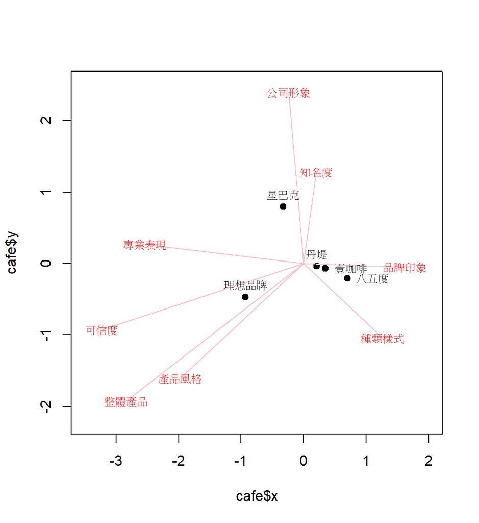

```r
plot(cafe$x, cafe$y, pch = 19, xlim=c(-3.5,2), ylim=c(-2.2,2.5))
for(i in 1:length(percepts)) {
  m = lm(sprintf("%s ~ x + y",percepts[i]), data=cafe)
  c = 1/m$coef[2]; d = 1/m$coef[3]
  cd2 = c*c + d*d
  px = (c * d * d)/cd2
  py = (c * c * d)/cd2
  arrows(0,0,px,py,col="pink",length=0)
  text(px, py, col="red", cex=0.75, labels = percepts[i])
}
text(cafe$x, cafe$y, pos=bpos, offset=0.5, cex=0.75, labels = brands)
```

```r
# pos=bpos:把字跟點分開
```

### 3. 主成分分析 PCA

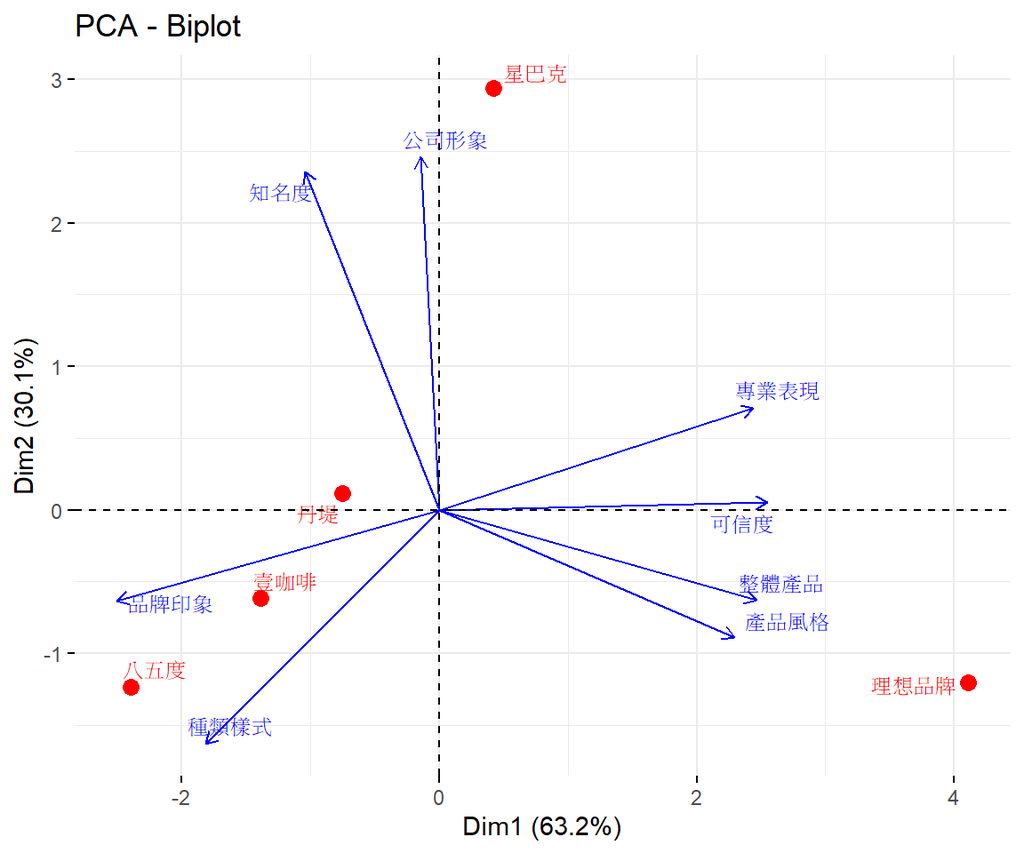

```r
PCA(cafe[1:8], graph=F) %>% fviz_pca_biplot(
  repel=T, col.var="blue", col.ind="red",
  labelsize=3, pointshape=16, pointsize=3)
```

🗿 問題討論：  
■ 請問你從品牌知覺圖之中觀察到哪一些現象？

🗿 問題：集群分析  
■ 為什麼要分群？ 好觀察  
■ 分群的依據？ 相似  
■ 集群分析的基本原理？ 距離  
■ 分群之前，如何選擇分群變數？  
■ 做集群分析之前，為甚麼要對分群變數做標準化？ 尺度統一  
■ 如何決定要分幾群？ 主觀  
■ 做分群之後，要如何觀察各分群的特徵？

🗿 問題：尺度縮減  
■ 為什麼要降維？ 好觀察  
■ 降維的基本原理？ 留下重要的變量  
■ 降維的好處？ 簡化  
■ 降維的壞處？ 損失  
■ 藉由降維空間的視覺化，我們可以觀察到哪三項重要的資訊？ 主成分、資料點、變量